# Sample Overlap Reconciliation: DivCo + AMP-AD 1.0

Mapping genotyped sample IDs to cohort metadata

2026-06-12

# 1 Genotyoe data

The genotyped data is the combined **DivCo + AMP-AD 1.0** set (syn67158725). The sample IDs in the VCF are a mix of identifiers from several contributing studies, and the goal here is to **generate combined individual, assay, and biospecimen metadata** by matching it to one of the source metadata files.

# 2 Genotype Data

The full genotyped list contains 1019 samples.

# 3 DivCo metadata

The Diverse Cohorts (DivCo) study provides three metadata tables — individual, assay (WGS), and biospecimen.

AMP-AD_DiverseCohorts_assay_WGS_metadata.csv is the DivCo metadata file (syn51757644) to which sample list will be matched using `specimenID` AMP-AD_DiverseCohorts_individual_metadata.csv (syn51757646) contains individual level data for DivCo cohort AMP-AD_DiverseCohorts_biospecimen_metadata.csv (syn51757645) contains individual to biospecimen mapping for DivCo cohort

The WGS metadata file contains 762 samples of which 743 samples are in DivCo + AMP-AD 1.0 jointcall VCFs

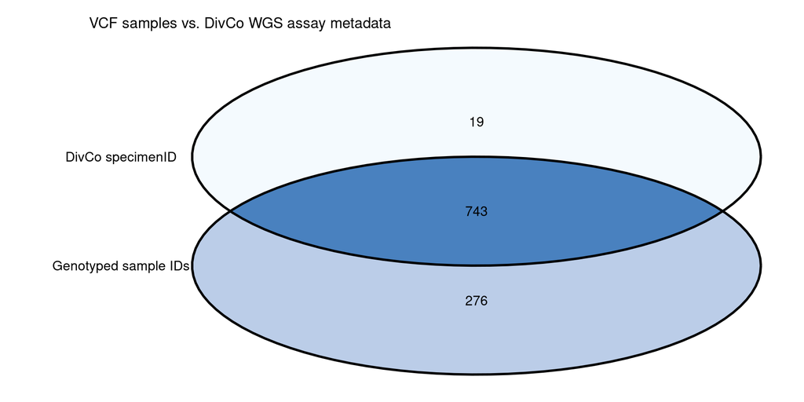

# 4 AMP-AD 1.0 metadata

The remaining genotyped samples come from the AMP-AD 1.0 studies (ROSMAP, MSBB, Mayo). Each is checked against its WGS assay metadata.

### 4.0.1 ROSMAP

ROSMAP_assay_wholeGenomeSeq_metadata.csv (syn21314542) is the Rosmap WGS metadata file to which sample list will be matched using `specimenID` ROSMAP_clinical.csv (syn3191087) is the Rosmap individual metadata file ROSMAP_biospecimen_metadata.csv (syn21323366) is the Rosmap biospecimen metadata file

The WGS metadata file contains 1196 samples of which 12 samples are in DivCo + AMP-AD 1.0 jointcall VCFs

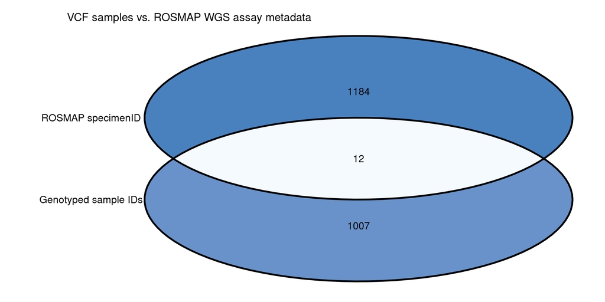

### 4.0.2 MSBB

MSBB_assay_wholeGenomeSeq_metadata.csv (syn22360825) is the MSBB WGS metadata file to which sample list will be matched using `specimenID` MSBB_individual_metadata.csv (syn6101474) is the MSBB individual metadata file MSBB_biospecimen_metadata.csv (syn21893059) is the MSBB biospecimen metadata file

The WGS metadata file contains 349 samples of which 0 samples are in DivCo + AMP-AD 1.0 jointcall VCFs

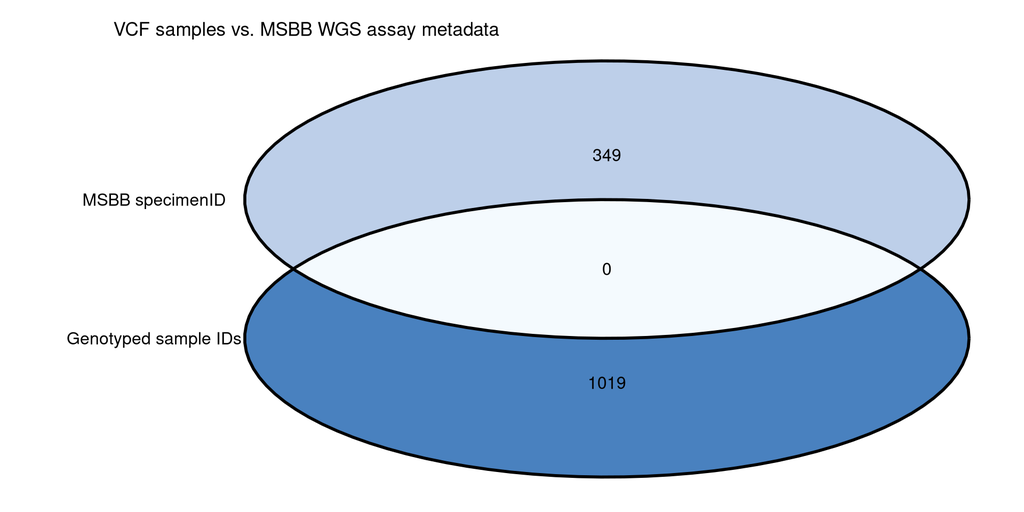

### 4.0.3 MayoRNAseq

MayoRNAseq_assay_wholeGenomeSeq_metadata.csv (syn23481994) is the Mayo WGS metadata file to which sample list will be matched using `specimenID` MayoRNAseq_individual_metadata.csv (syn23277389) is the Mayo individual metadata file MayoRNAseq_biospecimen_metadata.csv (syn20827192) is the Mayo biospecimen metadata file

The WGS metadata file contains 349 samples of which 94 samples are in DivCo + AMP-AD 1.0 jointcall VCFs

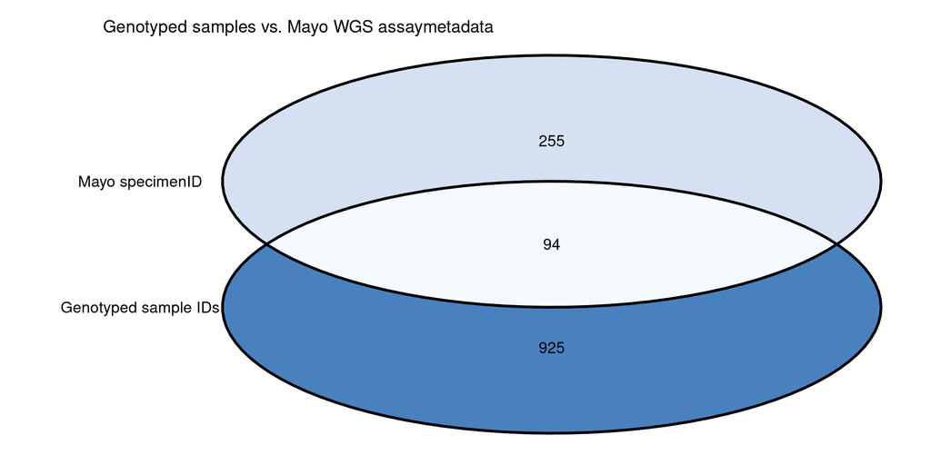

# 5 Combined overlap (first pass)

Accumulate every sample matched so far across DivCo and the three AMP-AD 1.0 studies, then see how many genotyped samples remain unaccounted for.

At this stage, 849 samples are accounted for and 170 samples are still unmatched — these are resolved below via the DivCo-to-AMP-AD 1.0 ID linking file.

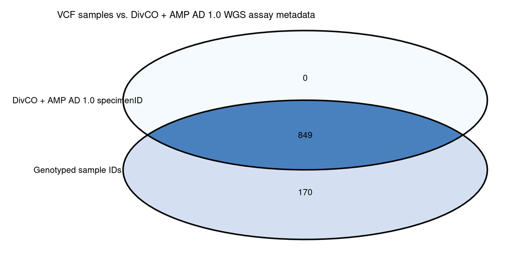

### Resolving ID-scheme mismatches (DivCo <-> AMP-AD 1.0) DivCo2_AMPAD1_IDlink2.csv (syn75361064) is a linking files for the n=276 AMP-AD1.0 samples in the DivCo + AMP 1.0 joint called sample set, listing the individualID and AMP-AD1.0 WGS specimenID (to link to AMP-AD1.0 metadata)

### 5.0.1 Mayo ID linking

The link file contains 94 samples from MayoRNAseq cohort of which 94 have been accounted for. These samples have identical individualID and specimenID and have multiple assay types (“wholeGenomeSeq” or “snpArray”) and specimenIDSource (“MayoBrainBank”, “BannerSun”, or “SNPs” ) associated with them in MayoRNAseq_biospecimen_metadata.csv

### 5.0.2 ROSMAP ID linking

The link file contains 182 samples from ROSMAP cohort of which 12 have been accounted for. These IDs had identical specimenID and individualID in ROSMAP_biospecimen_metadata.csv across assays and tissue types. They also have identical specimenID_WGS_AMPAD1 and individualID in the link file. The remaining 170 samples from the ROSMAP cohort in the link file have different specimenID and individualID in ROSMAP_biospecimen_metadata.csv (i.e. one specimenID for each tissue type). But the individualIDs were used for joint call sample labeling, so the overlap with specimenID fails for them.

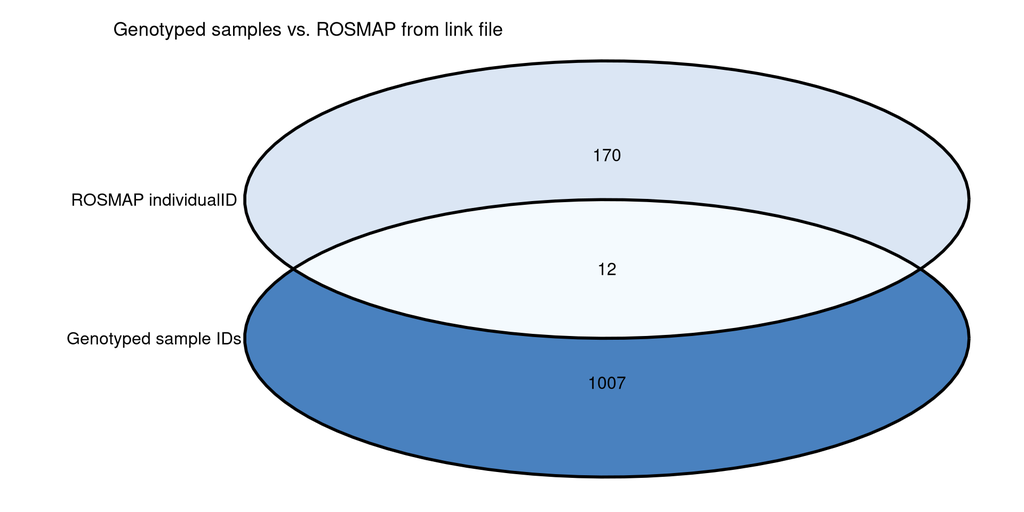

## 5.1 Final reconciliation

Add the ROSMAP donors that matched only via `individualID` (their `specimenID` was not in the genotyped list), then confirm how many samples remain unaccounted for.

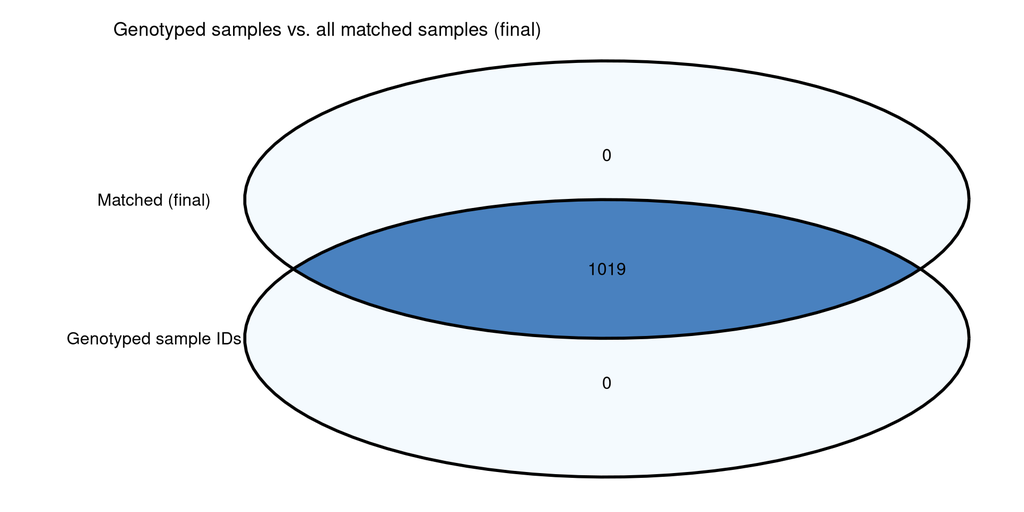

Of **1019** genotyped samples, **1019** are matched to a metadata source and **0** remain unaccounted for.

# 6 Filter data and create a combined metadata file

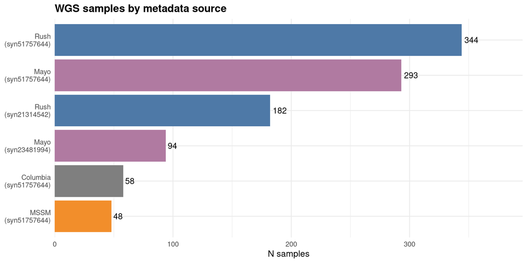

Metadata from each cohort was filtered and combined into unified metadata tables for WGS assay, biospecimen, and individual metadata.

**ROSMAP** requires special handling across all three tables: of the 182 ROSMAP samples, 12 have identical `individualID` and `specimenID`, while the remaining 170 use different IDs across the DivCo and AMP-AD 1.0 datasets. For all 182 samples, the AMP-AD 1.0 `specimenID` is retained in a new column (`specimenID_AMPAD_1.0`) and replaced with the DivCo-compatible `individualID` using the ID link file. Additionally, ROSMAP uses non-standard column names for several clinical variables (`msex` → `sex`, `age_death` → `ageDeath`, `pmi` → `PMI`, `apoe_genotype` → `apoeGenotype`, `braaksc` → `Braak`) which were harmonized prior to combining.

For the **WGS assay metadata**, `Total.Reads` → `totalReads` and `Mean.Read.Length` → `readLength` were harmonized across cohorts. Site labels (`Rush`, `Mayo`) were added for ROSMAP and Mayo samples as DivCo already contains a `Site` column. The final combined table contains 1019 samples across 4 sites.

For the **biospecimen metadata**, the following columns were retained across all three cohorts: `individualID`, `specimenID`, `organ`, `tissue`, `BrodmannArea`, `sampleStatus`, `nucleicAcidSource`, and `assay`. All tables were subset to `wholeGenomeSeq` assay only prior to combining. The final combined table contains 1019 samples.

For the **individual metadata**, the following columns were retained across all three cohorts: `individualID`, `sex`, `race`, `ageDeath`, `PMI`, `apoeGenotype`, and `Braak`. The final combined table contains 1019 individuals.

A `*_metadata_source` column was added to each combined table to track the originating Synapse file per cohort. All combined tables are saved to `~/data/processed/metadata/Combined/`.